# Risk Factor Analysis

## Outcome Variable

**Outcome Variable:** ever_wasted

## Predictor Variables

**Intervention Variable:** earlybf

**Adjustment Set:**

- arm
- sex
- W_mage
- meducyrs
- feducyrs
- hhwealth_quart
- hfoodsec
- W_mhtcm
- W_mwtkg
- W_mbmi
- vagbrth
- W_gagebrth
- W_birthwt
- W_birthlen
- W_nrooms
- W_nchldlt5
- brthmon
- W_parity
- impfloor
- impsan
- safeh20
- delta_W_mage
- delta_meducyrs
- delta_feducyrs
- delta_hhwealth_quart
- delta_hfoodsec
- delta_W_mhtcm
- delta_W_mwtkg
- delta_W_mbmi
- delta_vagbrth
- delta_W_gagebrth
- delta_W_birthwt
- delta_W_birthlen
- delta_W_nrooms
- delta_W_nchldlt5
- delta_brthmon
- delta_W_parity
- delta_impfloor
- delta_impsan
- delta_safeh20

## Stratifying Variables

The analysis was stratified on these variable(s):

- agecat
- studyid
- country

## Data Summary

| agecat | studyid | country | earlybf | ever_wasted | n_cell | n |
| --- | --- | --- | --- | --- | --- | --- |
| 0-24 months (no birth wast) | EE | PAKISTAN | 1 | 0 | 33 | 366 |
| 0-24 months (no birth wast) | EE | PAKISTAN | 1 | 1 | 35 | 366 |
| 0-24 months (no birth wast) | EE | PAKISTAN | 0 | 0 | 137 | 366 |
| 0-24 months (no birth wast) | EE | PAKISTAN | 0 | 1 | 161 | 366 |
| 0-24 months (no birth wast) | GMS-Nepal | NEPAL | 1 | 0 | 95 | 599 |
| 0-24 months (no birth wast) | GMS-Nepal | NEPAL | 1 | 1 | 77 | 599 |
| 0-24 months (no birth wast) | GMS-Nepal | NEPAL | 0 | 0 | 209 | 599 |
| 0-24 months (no birth wast) | GMS-Nepal | NEPAL | 0 | 1 | 218 | 599 |
| 0-24 months (no birth wast) | JiVitA-3 | BANGLADESH | 1 | 0 | 122 | 26458 |
| 0-24 months (no birth wast) | JiVitA-3 | BANGLADESH | 1 | 1 | 21 | 26458 |
| 0-24 months (no birth wast) | JiVitA-3 | BANGLADESH | 0 | 0 | 21842 | 26458 |
| 0-24 months (no birth wast) | JiVitA-3 | BANGLADESH | 0 | 1 | 4473 | 26458 |
| 0-24 months (no birth wast) | JiVitA-4 | BANGLADESH | 1 | 0 | 2528 | 5396 |
| 0-24 months (no birth wast) | JiVitA-4 | BANGLADESH | 1 | 1 | 886 | 5396 |
| 0-24 months (no birth wast) | JiVitA-4 | BANGLADESH | 0 | 0 | 1477 | 5396 |
| 0-24 months (no birth wast) | JiVitA-4 | BANGLADESH | 0 | 1 | 505 | 5396 |
| 0-24 months (no birth wast) | MAL-ED | BANGLADESH | 1 | 0 | 128 | 262 |
| 0-24 months (no birth wast) | MAL-ED | BANGLADESH | 1 | 1 | 33 | 262 |
| 0-24 months (no birth wast) | MAL-ED | BANGLADESH | 0 | 0 | 77 | 262 |
| 0-24 months (no birth wast) | MAL-ED | BANGLADESH | 0 | 1 | 24 | 262 |
| 0-24 months (no birth wast) | MAL-ED | BRAZIL | 1 | 0 | 103 | 233 |
| 0-24 months (no birth wast) | MAL-ED | BRAZIL | 1 | 1 | 5 | 233 |
| 0-24 months (no birth wast) | MAL-ED | BRAZIL | 0 | 0 | 117 | 233 |
| 0-24 months (no birth wast) | MAL-ED | BRAZIL | 0 | 1 | 8 | 233 |
| 0-24 months (no birth wast) | MAL-ED | INDIA | 1 | 0 | 90 | 245 |
| 0-24 months (no birth wast) | MAL-ED | INDIA | 1 | 1 | 56 | 245 |
| 0-24 months (no birth wast) | MAL-ED | INDIA | 0 | 0 | 64 | 245 |
| 0-24 months (no birth wast) | MAL-ED | INDIA | 0 | 1 | 35 | 245 |
| 0-24 months (no birth wast) | MAL-ED | NEPAL | 1 | 0 | 79 | 239 |
| 0-24 months (no birth wast) | MAL-ED | NEPAL | 1 | 1 | 18 | 239 |

[output cut: 82 more lines]

The following strata were considered:

- agecat: 0-24 months (no birth wast), studyid: EE, country: PAKISTAN
- agecat: 0-24 months (no birth wast), studyid: GMS-Nepal, country: NEPAL
- agecat: 0-24 months (no birth wast), studyid: JiVitA-3, country: BANGLADESH
- agecat: 0-24 months (no birth wast), studyid: JiVitA-4, country: BANGLADESH
- agecat: 0-24 months (no birth wast), studyid: MAL-ED, country: BANGLADESH
- agecat: 0-24 months (no birth wast), studyid: MAL-ED, country: BRAZIL
- agecat: 0-24 months (no birth wast), studyid: MAL-ED, country: INDIA
- agecat: 0-24 months (no birth wast), studyid: MAL-ED, country: NEPAL
- agecat: 0-24 months (no birth wast), studyid: MAL-ED, country: PERU
- agecat: 0-24 months (no birth wast), studyid: MAL-ED, country: SOUTH AFRICA
- agecat: 0-24 months (no birth wast), studyid: MAL-ED, country: TANZANIA, UNITED REPUBLIC OF
- agecat: 0-24 months (no birth wast), studyid: NIH-Crypto, country: BANGLADESH
- agecat: 0-24 months (no birth wast), studyid: SAS-CompFeed, country: INDIA
- agecat: 0-24 months (no birth wast), studyid: ZVITAMBO, country: ZIMBABWE
- agecat: 0-6 months (no birth wast), studyid: EE, country: PAKISTAN
- agecat: 0-6 months (no birth wast), studyid: GMS-Nepal, country: NEPAL
- agecat: 0-6 months (no birth wast), studyid: JiVitA-3, country: BANGLADESH
- agecat: 0-6 months (no birth wast), studyid: JiVitA-4, country: BANGLADESH
- agecat: 0-6 months (no birth wast), studyid: MAL-ED, country: BANGLADESH
- agecat: 0-6 months (no birth wast), studyid: MAL-ED, country: BRAZIL
- agecat: 0-6 months (no birth wast), studyid: MAL-ED, country: INDIA
- agecat: 0-6 months (no birth wast), studyid: MAL-ED, country: NEPAL
- agecat: 0-6 months (no birth wast), studyid: MAL-ED, country: PERU
- agecat: 0-6 months (no birth wast), studyid: MAL-ED, country: SOUTH AFRICA
- agecat: 0-6 months (no birth wast), studyid: MAL-ED, country: TANZANIA, UNITED REPUBLIC OF
- agecat: 0-6 months (no birth wast), studyid: NIH-Crypto, country: BANGLADESH
- agecat: 0-6 months (no birth wast), studyid: SAS-CompFeed, country: INDIA
- agecat: 0-6 months (no birth wast), studyid: ZVITAMBO, country: ZIMBABWE

### Dropped Strata

Some strata were dropped due to rare outcomes:

- agecat: 0-24 months (no birth wast), studyid: MAL-ED, country: PERU
- agecat: 0-24 months (no birth wast), studyid: MAL-ED, country: TANZANIA, UNITED REPUBLIC OF
- agecat: 0-6 months (no birth wast), studyid: MAL-ED, country: BRAZIL
- agecat: 0-6 months (no birth wast), studyid: MAL-ED, country: PERU
- agecat: 0-6 months (no birth wast), studyid: MAL-ED, country: SOUTH AFRICA
- agecat: 0-6 months (no birth wast), studyid: MAL-ED, country: TANZANIA, UNITED REPUBLIC OF
- agecat: 0-6 months (no birth wast), studyid: NIH-Crypto, country: BANGLADESH

## Methods Detail

We're interested in the causal parameters $E[Y_a]$ for all values of $a \in \mathcal{A}$. These parameters represent the mean outcome if, possibly contrary to fact, we intervened to set all units to have $A=a$. Under the randomization and positivity assumptions, these are identified by the statistical parameters $\psi_a=E_W[E_{Y|A,W}(Y|A=a,W)]$. In addition, we're interested in the mean of $Y$, $E[Y]$ under no intervention (the observed mean). We will estimate these parameters by using SuperLearner to fit the relevant likelihood factors -- $E_{Y|A,W}(Y|A=a,W)$ and $p(A=a|W)$, and then updating our likelihood fit using a joint TMLE.

For unadjusted analyses ($W=\{\}$), initial likelihoods were estimated using Lrnr_glm to estimate the simple $E(Y|A)$ and Lrnr_mean to estimate $p(A)$. For adjusted analyses, a small library containing Lrnr_glmnet, Lrnr_xgboost, and Lrnr_mean was used.

Having estimated these parameters, we will then use the delta method to estimate relative risks and attributable risks relative to a prespecified baseline level of $A$.

# Results Detail

## Results Plots

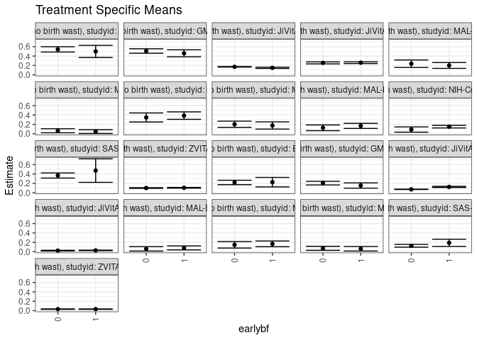

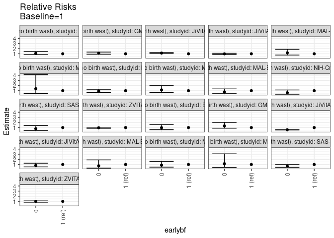

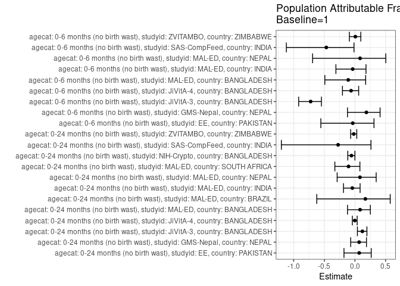

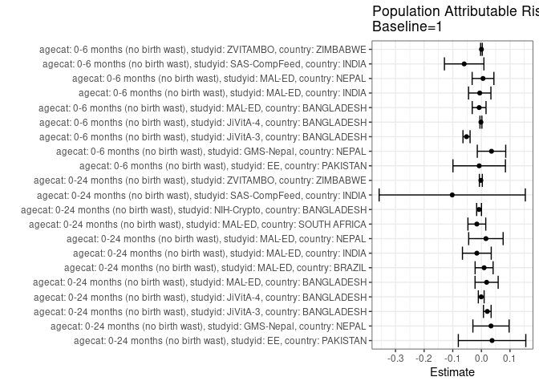

## Results Table

### Parameter: TSM

| agecat | studyid | country | intervention_level | baseline_level | estimate | ci_lower | ci_upper |
| --- | --- | --- | --- | --- | --- | --- | --- |
| 0-24 months (no birth wast) | EE | PAKISTAN | 1 | NA | 0.4982652 | 0.3686581 | 0.6278724 |
| 0-24 months (no birth wast) | EE | PAKISTAN | 0 | NA | 0.5423051 | 0.4858222 | 0.5987881 |
| 0-24 months (no birth wast) | GMS-Nepal | NEPAL | 1 | NA | 0.4589379 | 0.3843339 | 0.5335418 |
| 0-24 months (no birth wast) | GMS-Nepal | NEPAL | 0 | NA | 0.5078108 | 0.4604314 | 0.5551903 |
| 0-24 months (no birth wast) | JiVitA-3 | BANGLADESH | 1 | NA | 0.1492582 | 0.1366631 | 0.1618533 |
| 0-24 months (no birth wast) | JiVitA-3 | BANGLADESH | 0 | NA | 0.1699745 | 0.1645518 | 0.1753971 |
| 0-24 months (no birth wast) | JiVitA-4 | BANGLADESH | 1 | NA | 0.2583847 | 0.2405410 | 0.2762284 |
| 0-24 months (no birth wast) | JiVitA-4 | BANGLADESH | 0 | NA | 0.2542874 | 0.2333511 | 0.2752237 |
| 0-24 months (no birth wast) | MAL-ED | BANGLADESH | 1 | NA | 0.1993346 | 0.1375838 | 0.2610855 |
| 0-24 months (no birth wast) | MAL-ED | BANGLADESH | 0 | NA | 0.2361756 | 0.1564923 | 0.3158589 |
| 0-24 months (no birth wast) | MAL-ED | BRAZIL | 1 | NA | 0.0462963 | 0.0065817 | 0.0860109 |
| 0-24 months (no birth wast) | MAL-ED | BRAZIL | 0 | NA | 0.0640000 | 0.0210013 | 0.1069987 |
| 0-24 months (no birth wast) | MAL-ED | INDIA | 1 | NA | 0.3873215 | 0.3076857 | 0.4669573 |
| 0-24 months (no birth wast) | MAL-ED | INDIA | 0 | NA | 0.3474959 | 0.2513741 | 0.4436176 |
| 0-24 months (no birth wast) | MAL-ED | NEPAL | 1 | NA | 0.1766888 | 0.0996471 | 0.2537304 |
| 0-24 months (no birth wast) | MAL-ED | NEPAL | 0 | NA | 0.2021482 | 0.1353347 | 0.2689616 |
| 0-24 months (no birth wast) | MAL-ED | SOUTH AFRICA | 1 | NA | 0.1679405 | 0.1136625 | 0.2222186 |
| 0-24 months (no birth wast) | MAL-ED | SOUTH AFRICA | 0 | NA | 0.1270010 | 0.0659868 | 0.1880152 |
| 0-24 months (no birth wast) | NIH-Crypto | BANGLADESH | 1 | NA | 0.1513761 | 0.1238887 | 0.1788636 |
| 0-24 months (no birth wast) | NIH-Crypto | BANGLADESH | 0 | NA | 0.0900000 | 0.0338722 | 0.1461278 |
| 0-24 months (no birth wast) | SAS-CompFeed | INDIA | 1 | NA | 0.4725361 | 0.2208702 | 0.7242019 |
| 0-24 months (no birth wast) | SAS-CompFeed | INDIA | 0 | NA | 0.3669072 | 0.3124769 | 0.4213376 |
| 0-24 months (no birth wast) | ZVITAMBO | ZIMBABWE | 1 | NA | 0.1047291 | 0.0972034 | 0.1122548 |
| 0-24 months (no birth wast) | ZVITAMBO | ZIMBABWE | 0 | NA | 0.1003320 | 0.0923430 | 0.1083210 |
| 0-6 months (no birth wast) | EE | PAKISTAN | 1 | NA | 0.2247370 | 0.1237379 | 0.3257362 |
| 0-6 months (no birth wast) | EE | PAKISTAN | 0 | NA | 0.2184810 | 0.1713493 | 0.2656128 |
| 0-6 months (no birth wast) | GMS-Nepal | NEPAL | 1 | NA | 0.1537028 | 0.0972542 | 0.2101513 |
| 0-6 months (no birth wast) | GMS-Nepal | NEPAL | 0 | NA | 0.2042671 | 0.1655145 | 0.2430197 |
| 0-6 months (no birth wast) | JiVitA-3 | BANGLADESH | 1 | NA | 0.1238825 | 0.1118966 | 0.1358684 |
| 0-6 months (no birth wast) | JiVitA-3 | BANGLADESH | 0 | NA | 0.0716183 | 0.0678774 | 0.0753593 |
| 0-6 months (no birth wast) | JiVitA-4 | BANGLADESH | 1 | NA | 0.0272381 | 0.0210286 | 0.0334476 |
| 0-6 months (no birth wast) | JiVitA-4 | BANGLADESH | 0 | NA | 0.0223408 | 0.0147337 | 0.0299479 |
| 0-6 months (no birth wast) | MAL-ED | BANGLADESH | 1 | NA | 0.0807453 | 0.0385810 | 0.1229097 |
| 0-6 months (no birth wast) | MAL-ED | BANGLADESH | 0 | NA | 0.0600000 | 0.0133640 | 0.1066360 |
| 0-6 months (no birth wast) | MAL-ED | INDIA | 1 | NA | 0.1663269 | 0.1051262 | 0.2275276 |
| 0-6 months (no birth wast) | MAL-ED | INDIA | 0 | NA | 0.1462831 | 0.0769912 | 0.2155750 |
| 0-6 months (no birth wast) | MAL-ED | NEPAL | 1 | NA | 0.0618557 | 0.0138155 | 0.1098959 |
| 0-6 months (no birth wast) | MAL-ED | NEPAL | 0 | NA | 0.0714286 | 0.0286776 | 0.1141795 |
| 0-6 months (no birth wast) | SAS-CompFeed | INDIA | 1 | NA | 0.1890047 | 0.1120398 | 0.2659695 |
| 0-6 months (no birth wast) | SAS-CompFeed | INDIA | 0 | NA | 0.1253717 | 0.0960253 | 0.1547180 |
| 0-6 months (no birth wast) | ZVITAMBO | ZIMBABWE | 1 | NA | 0.0318835 | 0.0275341 | 0.0362328 |
| 0-6 months (no birth wast) | ZVITAMBO | ZIMBABWE | 0 | NA | 0.0323536 | 0.0275743 | 0.0371329 |

### Parameter: E(Y)

| agecat | studyid | country | intervention_level | baseline_level | estimate | ci_lower | ci_upper |
| --- | --- | --- | --- | --- | --- | --- | --- |
| 0-24 months (no birth wast) | EE | PAKISTAN | NA | NA | 0.5355191 | 0.4843541 | 0.5866841 |
| 0-24 months (no birth wast) | GMS-Nepal | NEPAL | NA | NA | 0.4924875 | 0.4524176 | 0.5325574 |
| 0-24 months (no birth wast) | JiVitA-3 | BANGLADESH | NA | NA | 0.1698541 | 0.1645584 | 0.1751498 |
| 0-24 months (no birth wast) | JiVitA-4 | BANGLADESH | NA | NA | 0.2577835 | 0.2441424 | 0.2714247 |
| 0-24 months (no birth wast) | MAL-ED | BANGLADESH | NA | NA | 0.2175573 | 0.1675030 | 0.2676115 |
| 0-24 months (no birth wast) | MAL-ED | BRAZIL | NA | NA | 0.0557940 | 0.0262594 | 0.0853286 |
| 0-24 months (no birth wast) | MAL-ED | INDIA | NA | NA | 0.3714286 | 0.3108013 | 0.4320559 |
| 0-24 months (no birth wast) | MAL-ED | NEPAL | NA | NA | 0.1924686 | 0.1423823 | 0.2425550 |
| 0-24 months (no birth wast) | MAL-ED | SOUTH AFRICA | NA | NA | 0.1520270 | 0.1110549 | 0.1929992 |
| 0-24 months (no birth wast) | NIH-Crypto | BANGLADESH | NA | NA | 0.1432361 | 0.1182149 | 0.1682572 |
| 0-24 months (no birth wast) | SAS-CompFeed | INDIA | NA | NA | 0.3706485 | 0.3201448 | 0.4211521 |
| 0-24 months (no birth wast) | ZVITAMBO | ZIMBABWE | NA | NA | 0.1027945 | 0.0973901 | 0.1081989 |
| 0-6 months (no birth wast) | EE | PAKISTAN | NA | NA | 0.2170330 | 0.1746268 | 0.2594392 |
| 0-6 months (no birth wast) | GMS-Nepal | NEPAL | NA | NA | 0.1890034 | 0.1571685 | 0.2208384 |
| 0-6 months (no birth wast) | JiVitA-3 | BANGLADESH | NA | NA | 0.0718927 | 0.0682457 | 0.0755397 |
| 0-6 months (no birth wast) | JiVitA-4 | BANGLADESH | NA | NA | 0.0256203 | 0.0209093 | 0.0303314 |
| 0-6 months (no birth wast) | MAL-ED | BANGLADESH | NA | NA | 0.0727969 | 0.0412174 | 0.1043764 |
| 0-6 months (no birth wast) | MAL-ED | INDIA | NA | NA | 0.1604938 | 0.1142470 | 0.2067406 |
| 0-6 months (no birth wast) | MAL-ED | NEPAL | NA | NA | 0.0675105 | 0.0354995 | 0.0995216 |
| 0-6 months (no birth wast) | SAS-CompFeed | INDIA | NA | NA | 0.1288301 | 0.0985331 | 0.1591271 |
| 0-6 months (no birth wast) | ZVITAMBO | ZIMBABWE | NA | NA | 0.0321008 | 0.0289337 | 0.0352680 |

### Parameter: RR

| agecat | studyid | country | intervention_level | baseline_level | estimate | ci_lower | ci_upper |
| --- | --- | --- | --- | --- | --- | --- | --- |
| 0-24 months (no birth wast) | EE | PAKISTAN | 1 | 1 | 1.0000000 | 1.0000000 | 1.0000000 |
| 0-24 months (no birth wast) | EE | PAKISTAN | 0 | 1 | 1.0883865 | 0.8230992 | 1.4391767 |
| 0-24 months (no birth wast) | GMS-Nepal | NEPAL | 1 | 1 | 1.0000000 | 1.0000000 | 1.0000000 |
| 0-24 months (no birth wast) | GMS-Nepal | NEPAL | 0 | 1 | 1.1064915 | 0.9183566 | 1.3331678 |
| 0-24 months (no birth wast) | JiVitA-3 | BANGLADESH | 1 | 1 | 1.0000000 | 1.0000000 | 1.0000000 |
| 0-24 months (no birth wast) | JiVitA-3 | BANGLADESH | 0 | 1 | 1.1387951 | 1.0405670 | 1.2462958 |
| 0-24 months (no birth wast) | JiVitA-4 | BANGLADESH | 1 | 1 | 1.0000000 | 1.0000000 | 1.0000000 |
| 0-24 months (no birth wast) | JiVitA-4 | BANGLADESH | 0 | 1 | 0.9841427 | 0.8838791 | 1.0957797 |
| 0-24 months (no birth wast) | MAL-ED | BANGLADESH | 1 | 1 | 1.0000000 | 1.0000000 | 1.0000000 |
| 0-24 months (no birth wast) | MAL-ED | BANGLADESH | 0 | 1 | 1.1848196 | 0.7480343 | 1.8766487 |
| 0-24 months (no birth wast) | MAL-ED | BRAZIL | 1 | 1 | 1.0000000 | 1.0000000 | 1.0000000 |
| 0-24 months (no birth wast) | MAL-ED | BRAZIL | 0 | 1 | 1.3824000 | 0.4649629 | 4.1100691 |
| 0-24 months (no birth wast) | MAL-ED | INDIA | 1 | 1 | 1.0000000 | 1.0000000 | 1.0000000 |
| 0-24 months (no birth wast) | MAL-ED | INDIA | 0 | 1 | 0.8971768 | 0.6357125 | 1.2661794 |
| 0-24 months (no birth wast) | MAL-ED | NEPAL | 1 | 1 | 1.0000000 | 1.0000000 | 1.0000000 |
| 0-24 months (no birth wast) | MAL-ED | NEPAL | 0 | 1 | 1.1440918 | 0.6618009 | 1.9778548 |
| 0-24 months (no birth wast) | MAL-ED | SOUTH AFRICA | 1 | 1 | 1.0000000 | 1.0000000 | 1.0000000 |
| 0-24 months (no birth wast) | MAL-ED | SOUTH AFRICA | 0 | 1 | 0.7562260 | 0.4244847 | 1.3472281 |
| 0-24 months (no birth wast) | NIH-Crypto | BANGLADESH | 1 | 1 | 1.0000000 | 1.0000000 | 1.0000000 |
| 0-24 months (no birth wast) | NIH-Crypto | BANGLADESH | 0 | 1 | 0.5945455 | 0.3105227 | 1.1383526 |
| 0-24 months (no birth wast) | SAS-CompFeed | INDIA | 1 | 1 | 1.0000000 | 1.0000000 | 1.0000000 |
| 0-24 months (no birth wast) | SAS-CompFeed | INDIA | 0 | 1 | 0.7764640 | 0.4333268 | 1.3913202 |
| 0-24 months (no birth wast) | ZVITAMBO | ZIMBABWE | 1 | 1 | 1.0000000 | 1.0000000 | 1.0000000 |
| 0-24 months (no birth wast) | ZVITAMBO | ZIMBABWE | 0 | 1 | 0.9580144 | 0.8612330 | 1.0656716 |
| 0-6 months (no birth wast) | EE | PAKISTAN | 1 | 1 | 1.0000000 | 1.0000000 | 1.0000000 |
| 0-6 months (no birth wast) | EE | PAKISTAN | 0 | 1 | 0.9721630 | 0.5903109 | 1.6010222 |
| 0-6 months (no birth wast) | GMS-Nepal | NEPAL | 1 | 1 | 1.0000000 | 1.0000000 | 1.0000000 |
| 0-6 months (no birth wast) | GMS-Nepal | NEPAL | 0 | 1 | 1.3289750 | 0.8787375 | 2.0099001 |
| 0-6 months (no birth wast) | JiVitA-3 | BANGLADESH | 1 | 1 | 1.0000000 | 1.0000000 | 1.0000000 |
| 0-6 months (no birth wast) | JiVitA-3 | BANGLADESH | 0 | 1 | 0.5781148 | 0.5168665 | 0.6466210 |
| 0-6 months (no birth wast) | JiVitA-4 | BANGLADESH | 1 | 1 | 1.0000000 | 1.0000000 | 1.0000000 |
| 0-6 months (no birth wast) | JiVitA-4 | BANGLADESH | 0 | 1 | 0.8202043 | 0.5372659 | 1.2521455 |
| 0-6 months (no birth wast) | MAL-ED | BANGLADESH | 1 | 1 | 1.0000000 | 1.0000000 | 1.0000000 |
| 0-6 months (no birth wast) | MAL-ED | BANGLADESH | 0 | 1 | 0.7430769 | 0.2913165 | 1.8954069 |
| 0-6 months (no birth wast) | MAL-ED | INDIA | 1 | 1 | 1.0000000 | 1.0000000 | 1.0000000 |
| 0-6 months (no birth wast) | MAL-ED | INDIA | 0 | 1 | 0.8794919 | 0.4801950 | 1.6108164 |
| 0-6 months (no birth wast) | MAL-ED | NEPAL | 1 | 1 | 1.0000000 | 1.0000000 | 1.0000000 |
| 0-6 months (no birth wast) | MAL-ED | NEPAL | 0 | 1 | 1.1547619 | 0.4331731 | 3.0783885 |
| 0-6 months (no birth wast) | SAS-CompFeed | INDIA | 1 | 1 | 1.0000000 | 1.0000000 | 1.0000000 |
| 0-6 months (no birth wast) | SAS-CompFeed | INDIA | 0 | 1 | 0.6633258 | 0.4480001 | 0.9821451 |
| 0-6 months (no birth wast) | ZVITAMBO | ZIMBABWE | 1 | 1 | 1.0000000 | 1.0000000 | 1.0000000 |
| 0-6 months (no birth wast) | ZVITAMBO | ZIMBABWE | 0 | 1 | 1.0147461 | 0.8301411 | 1.2404032 |

### Parameter: PAR

| agecat | studyid | country | intervention_level | baseline_level | estimate | ci_lower | ci_upper |
| --- | --- | --- | --- | --- | --- | --- | --- |
| 0-24 months (no birth wast) | EE | PAKISTAN | 1 | NA | 0.0372539 | -0.0806073 | 0.1551151 |
| 0-24 months (no birth wast) | GMS-Nepal | NEPAL | 1 | NA | 0.0335496 | -0.0297167 | 0.0968159 |
| 0-24 months (no birth wast) | JiVitA-3 | BANGLADESH | 1 | NA | 0.0205959 | 0.0072265 | 0.0339654 |
| 0-24 months (no birth wast) | JiVitA-4 | BANGLADESH | 1 | NA | -0.0006012 | -0.0107351 | 0.0095327 |
| 0-24 months (no birth wast) | MAL-ED | BANGLADESH | 1 | NA | 0.0182226 | -0.0221295 | 0.0585748 |
| 0-24 months (no birth wast) | MAL-ED | BRAZIL | 1 | NA | 0.0094977 | -0.0219248 | 0.0409202 |
| 0-24 months (no birth wast) | MAL-ED | INDIA | 1 | NA | -0.0158929 | -0.0661628 | 0.0343769 |
| 0-24 months (no birth wast) | MAL-ED | NEPAL | 1 | NA | 0.0157799 | -0.0443626 | 0.0759223 |
| 0-24 months (no birth wast) | MAL-ED | SOUTH AFRICA | 1 | NA | -0.0159135 | -0.0470224 | 0.0151953 |
| 0-24 months (no birth wast) | NIH-Crypto | BANGLADESH | 1 | NA | -0.0081401 | -0.0165611 | 0.0002810 |
| 0-24 months (no birth wast) | SAS-CompFeed | INDIA | 1 | NA | -0.1018876 | -0.3572371 | 0.1534619 |
| 0-24 months (no birth wast) | ZVITAMBO | ZIMBABWE | 1 | NA | -0.0019346 | -0.0070865 | 0.0032173 |
| 0-6 months (no birth wast) | EE | PAKISTAN | 1 | NA | -0.0077041 | -0.0993517 | 0.0839436 |
| 0-6 months (no birth wast) | GMS-Nepal | NEPAL | 1 | NA | 0.0353007 | -0.0143405 | 0.0849418 |
| 0-6 months (no birth wast) | JiVitA-3 | BANGLADESH | 1 | NA | -0.0519898 | -0.0643895 | -0.0395902 |
| 0-6 months (no birth wast) | JiVitA-4 | BANGLADESH | 1 | NA | -0.0016178 | -0.0050282 | 0.0017927 |
| 0-6 months (no birth wast) | MAL-ED | BANGLADESH | 1 | NA | -0.0079484 | -0.0320680 | 0.0161712 |
| 0-6 months (no birth wast) | MAL-ED | INDIA | 1 | NA | -0.0058330 | -0.0448940 | 0.0332280 |
| 0-6 months (no birth wast) | MAL-ED | NEPAL | 1 | NA | 0.0056549 | -0.0323377 | 0.0436474 |
| 0-6 months (no birth wast) | SAS-CompFeed | INDIA | 1 | NA | -0.0601746 | -0.1291244 | 0.0087752 |
| 0-6 months (no birth wast) | ZVITAMBO | ZIMBABWE | 1 | NA | 0.0002174 | -0.0027716 | 0.0032063 |

### Parameter: PAF

| agecat | studyid | country | intervention_level | baseline_level | estimate | ci_lower | ci_upper |
| --- | --- | --- | --- | --- | --- | --- | --- |
| 0-24 months (no birth wast) | EE | PAKISTAN | 1 | NA | 0.0695660 | -0.1790604 | 0.2657650 |
| 0-24 months (no birth wast) | GMS-Nepal | NEPAL | 1 | NA | 0.0681228 | -0.0696998 | 0.1881879 |
| 0-24 months (no birth wast) | JiVitA-3 | BANGLADESH | 1 | NA | 0.1212566 | 0.0402282 | 0.1954442 |
| 0-24 months (no birth wast) | JiVitA-4 | BANGLADESH | 1 | NA | -0.0023321 | -0.0424113 | 0.0362062 |
| 0-24 months (no birth wast) | MAL-ED | BANGLADESH | 1 | NA | 0.0837601 | -0.1211781 | 0.2512380 |
| 0-24 months (no birth wast) | MAL-ED | BRAZIL | 1 | NA | 0.1702279 | -0.6229402 | 0.5757566 |
| 0-24 months (no birth wast) | MAL-ED | INDIA | 1 | NA | -0.0427887 | -0.1873298 | 0.0841565 |
| 0-24 months (no birth wast) | MAL-ED | NEPAL | 1 | NA | 0.0819867 | -0.2903352 | 0.3468763 |
| 0-24 months (no birth wast) | MAL-ED | SOUTH AFRICA | 1 | NA | -0.1046756 | -0.3278264 | 0.0809731 |
| 0-24 months (no birth wast) | NIH-Crypto | BANGLADESH | 1 | NA | -0.0568298 | -0.1167117 | -0.0001589 |
| 0-24 months (no birth wast) | SAS-CompFeed | INDIA | 1 | NA | -0.2748901 | -1.2012853 | 0.2616383 |
| 0-24 months (no birth wast) | ZVITAMBO | ZIMBABWE | 1 | NA | -0.0188202 | -0.0701859 | 0.0300801 |
| 0-6 months (no birth wast) | EE | PAKISTAN | 1 | NA | -0.0354973 | -0.5569573 | 0.3113140 |
| 0-6 months (no birth wast) | GMS-Nepal | NEPAL | 1 | NA | 0.1867726 | -0.1218433 | 0.4104892 |
| 0-6 months (no birth wast) | JiVitA-3 | BANGLADESH | 1 | NA | -0.7231592 | -0.9188796 | -0.5474017 |
| 0-6 months (no birth wast) | JiVitA-4 | BANGLADESH | 1 | NA | -0.0631438 | -0.2035811 | 0.0609068 |
| 0-6 months (no birth wast) | MAL-ED | BANGLADESH | 1 | NA | -0.1091860 | -0.4915374 | 0.1751507 |
| 0-6 months (no birth wast) | MAL-ED | INDIA | 1 | NA | -0.0363443 | -0.3106655 | 0.1805617 |
| 0-6 months (no birth wast) | MAL-ED | NEPAL | 1 | NA | 0.0837629 | -0.6911428 | 0.5035958 |
| 0-6 months (no birth wast) | SAS-CompFeed | INDIA | 1 | NA | -0.4670848 | -1.1196323 | -0.0154298 |
| 0-6 months (no birth wast) | ZVITAMBO | ZIMBABWE | 1 | NA | 0.0067710 | -0.0908462 | 0.0956528 |